# STATS 326/786

Assignment 02

**General comments:**

- All the plots should be labelled appropriately (axes, legends, titles).
- Please submit both your `.Rmd`, and the generated output file `.html` or `.pdf` on Canvas before the due date/time.
- Please make sure that the `.Rmd` file compiles without any errors. The marker will not spend time fixing the bugs in your code.
- Please avoid specifying absolute paths.
- Your submission must be original, and if we recognize that you have copied answers from another student in the course, we will deduct your marks.
- You will need to use the `tidyverse` and `fpp3` libraries for this assignment.
- IMPORTANT NOTE: There are some questions that are for STATS 786 only. Students taking STATS 326, while you are welcome to attempt these questions, please do not submit answers to them.

**Due: Friday 29 March 2024 at 16:00 PM (NZ time)**

# Problem 1: Monthly Average Auckland Temperatures

In Assignment 1, you investigated monthly average temperatures in Auckland. In this problem, you will do some further analysis. The data set `auckland_temps.csv` contains the monthly average temperatures in Auckland from July 1994 until January 2024. The time series plot is given below.

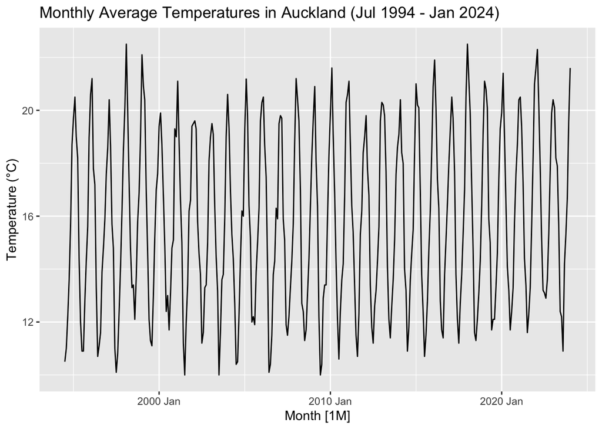

> 1. 7 Marks
> - Without using the `box_cox` function in the `feasts` package, create a new variable by manually performing a Box-Cox transformation on `Temperature` with $\lambda = 0.5$.
> - Plot the Box-Cox transformed `Temperature` time series and correlogram (setting `lag_max = 36`).
> - Comment on the patterns you observe in the correlogram. Hint: Think about your answer to the lag plot question in Assignment 1.

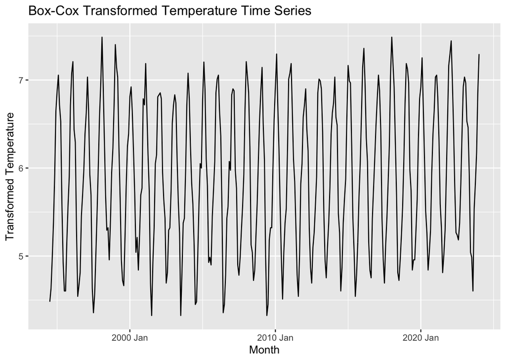

```r
lambda = 0.5
data <- data %>%
  mutate(Temperature_trasformed = (Temperature^lambda - 1) / lambda)

data %>%
  autoplot(Temperature_trasformed) +
  labs(title = "Box-Cox Transformed Temperature Time Series",
       x = "Month",
       y = "Transformed Temperature")
```

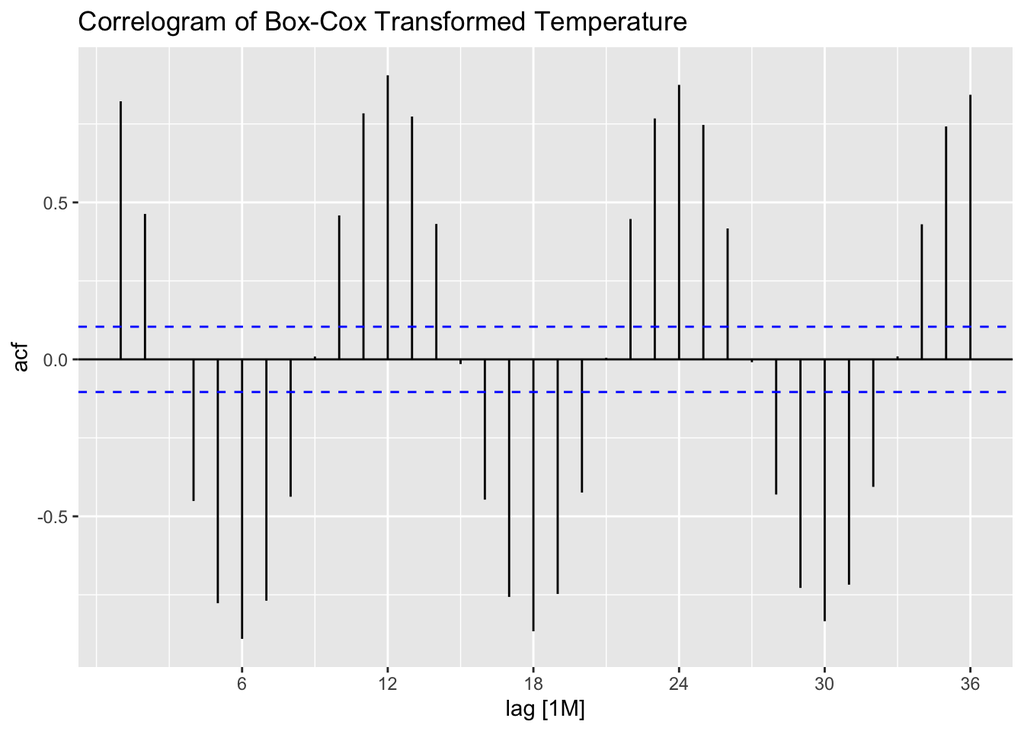

```r
data %>%
  ACF(Temperature_trasformed, lag_max = 36) %>%
  autoplot() +
  labs(title = "Correlogram of Box-Cox Transformed Temperature")
```

```r
### Comment: The correlogram graph exhibits clear seasonality, as temperatures cycle through the twelve months of the year. At a lag of 6, the seasons are opposite so it displays a strong negtive correlation, while at a lag of 12, representing a complete cycle of the four seasons, the seasons are the same, and the temperatures are almost identical, displaying a strong positive correlation.
```

> 2. 7 Marks
> - Perform an STL decomposition on the Box-Cox transformed temperatures. Keep the defaults for the trend and seasonal components, but specify `robust = TRUE` for the remainder component.
> - Plot the time series decomposition and comment on features you observe in the three components of the time series. Do you believe average temperatures in Auckland are rising? (Yes or no).

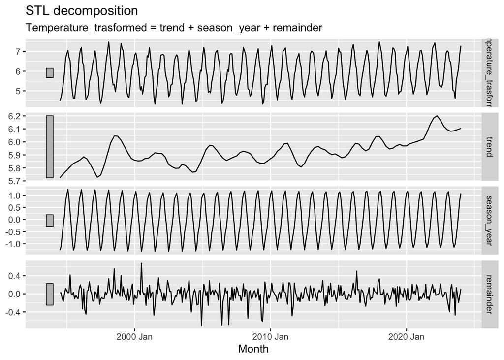

```r
dcmp <- data %>%
  model(stl = STL(Temperature_trasformed, robust = TRUE))
components(dcmp) %>%
  autoplot()
```